# # Red, Red Wine by Jennifer Bradford

### Everything I know about red wine all in one file

[output not shown]

```
## 'data.frame':    1599 obs. of  13 variables:
##  $ X                   : int  1 2 3 4 5 6 7 8 9 10 ...
##  $ fixed.acidity       : num  7.4 7.8 7.8 11.2 7.4 7.4 7.9 7.3 7.8 7.5 ...
##  $ volatile.acidity    : num  0.7 0.88 0.76 0.28 0.7 0.66 0.6 0.65 0.58 0.5 ...
##  $ citric.acid         : num  0 0 0.04 0.56 0 0 0.06 0 0.02 0.36 ...
##  $ residual.sugar      : num  1.9 2.6 2.3 1.9 1.9 1.8 1.6 1.2 2 6.1 ...
##  $ chlorides           : num  0.076 0.098 0.092 0.075 0.076 0.075 0.069 0.065 0.073 0.071 ...
##  $ free.sulfur.dioxide : num  11 25 15 17 11 13 15 15 9 17 ...
##  $ total.sulfur.dioxide: num  34 67 54 60 34 40 59 21 18 102 ...
##  $ density             : num  0.998 0.997 0.997 0.998 0.998 ...
##  $ pH                  : num  3.51 3.2 3.26 3.16 3.51 3.51 3.3 3.39 3.36 3.35 ...
##  $ sulphates           : num  0.56 0.68 0.65 0.58 0.56 0.56 0.46 0.47 0.57 0.8 ...
##  $ alcohol             : num  9.4 9.8 9.8 9.8 9.4 9.4 9.4 10 9.5 10.5 ...
##  $ quality             : int  5 5 5 6 5 5 5 7 7 5 ...
```

### The data consists of 12 variables of components, properties, alcohol

### content, and quality of 1599 red wines. I will look at which properties

# Univariate Plots Section

### We’ll look at each variable individually starting with quality distribution

```
##    Min. 1st Qu.  Median    Mean 3rd Qu.    Max.
##   3.000   5.000   6.000   5.636   6.000   8.000
```

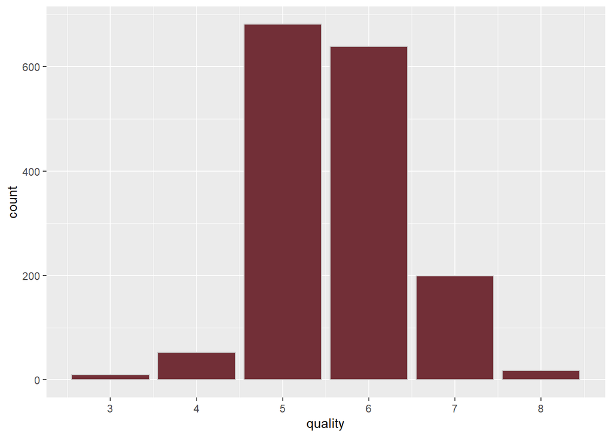

### Now let’s look at acidity, fixed then volatile

```
##    Min. 1st Qu.  Median    Mean 3rd Qu.    Max.
##    4.60    7.10    7.90    8.32    9.20   15.90
```

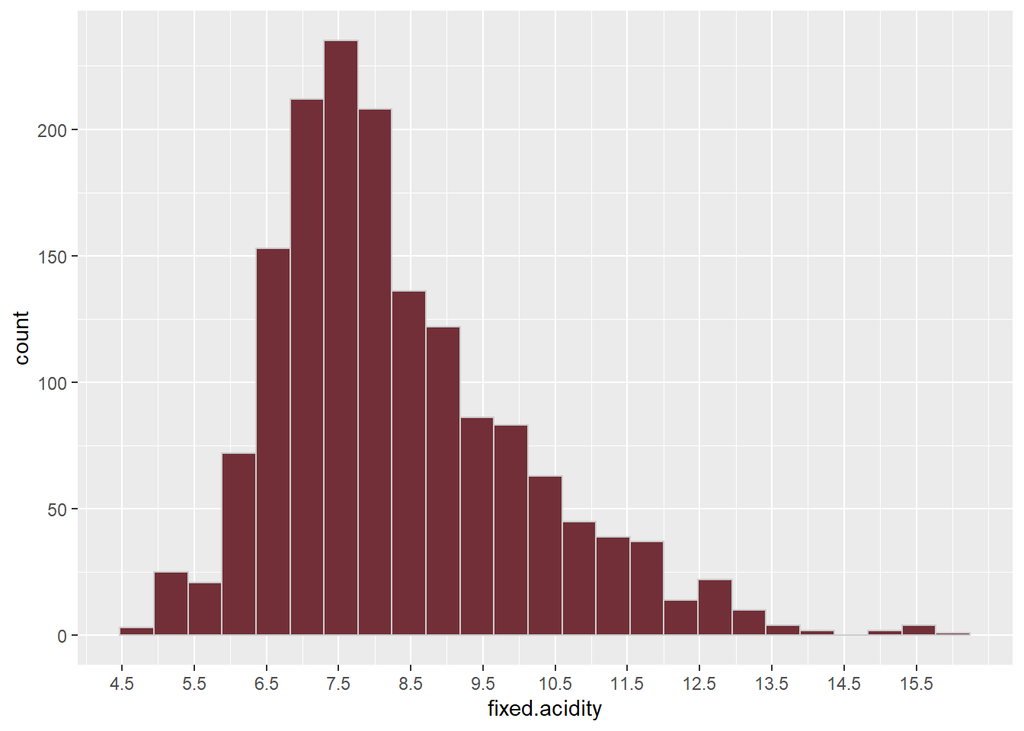

```
##    Min. 1st Qu.  Median    Mean 3rd Qu.    Max.
##  0.1200  0.3900  0.5200  0.5278  0.6400  1.5800
```

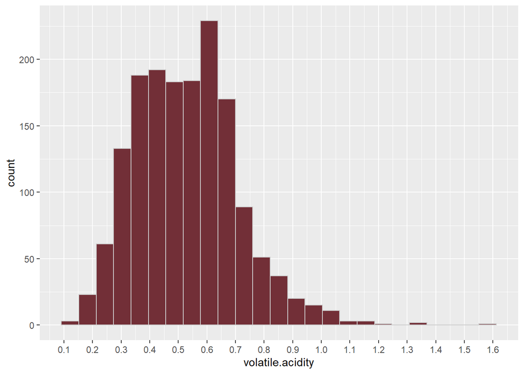

### There isn’t a variable for whether it tastes good or not so let’s just go

### look at sweetness. My guess is this one is matches up with quality, but

### then again, there are people who like coffee with no milk so…

```
##    Min. 1st Qu.  Median    Mean 3rd Qu.    Max.
##   0.900   1.900   2.200   2.539   2.600  15.500
```

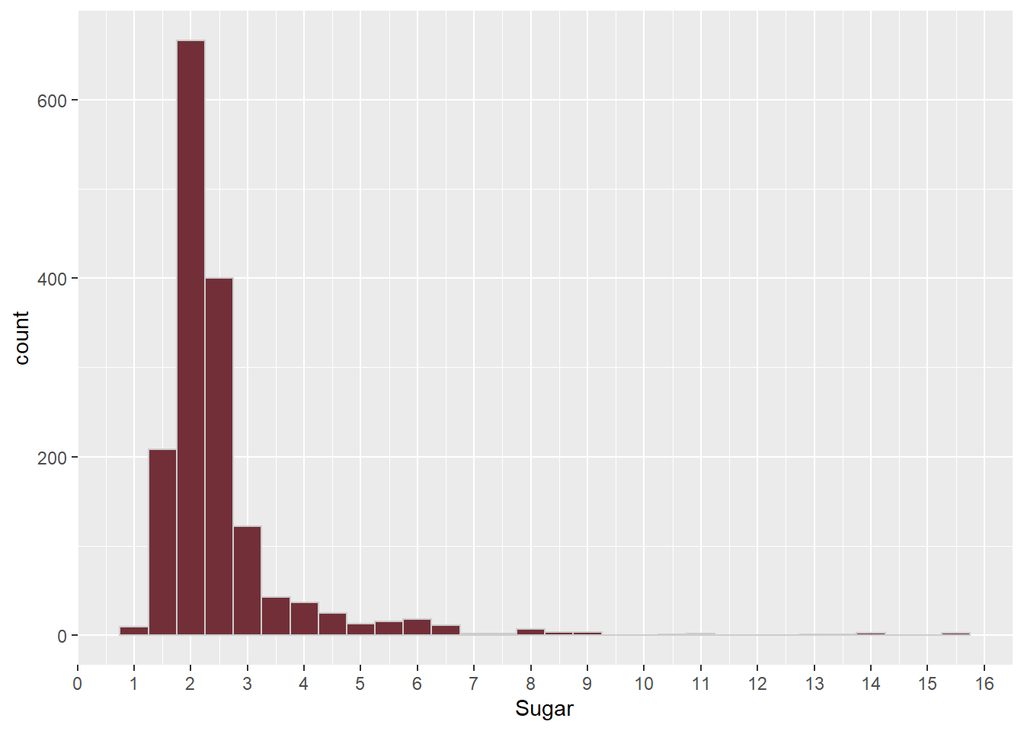

### ok for something made of grapes, this stuff doesn’t have much sugar and

### maybe it’s having less sugar that’s a good thing? A few outliers here where

### there’s a ton of sugar. If I drank wine, that would be my spot

### Does citric acid taste good? Who knows. OJ is good

```
##    Min. 1st Qu.  Median    Mean 3rd Qu.    Max.
##   0.000   0.090   0.260   0.271   0.420   1.000
```

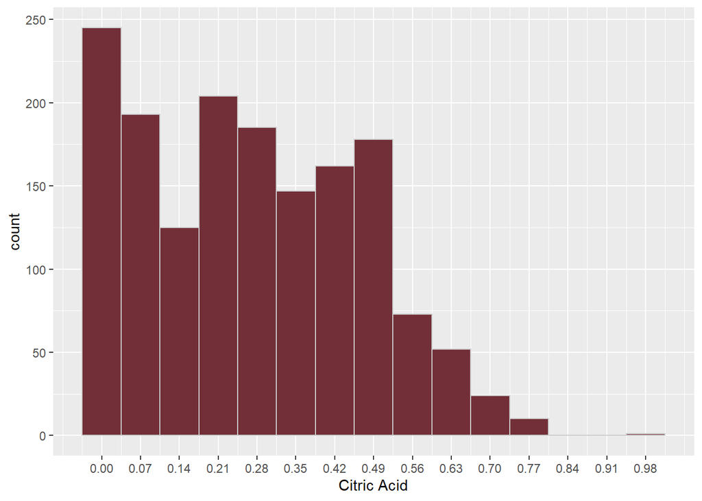

### There’s wine with no citric acid? Is this made from GMO grapes or is there

### jail wine made from bread in the mix here?

### Ok, on to the sulphur dioxide. I know this preservative is in soda and can

### cause asthma attacks. Why are there preservatives added to something that’s

### supposed to get better the longer it sits around?

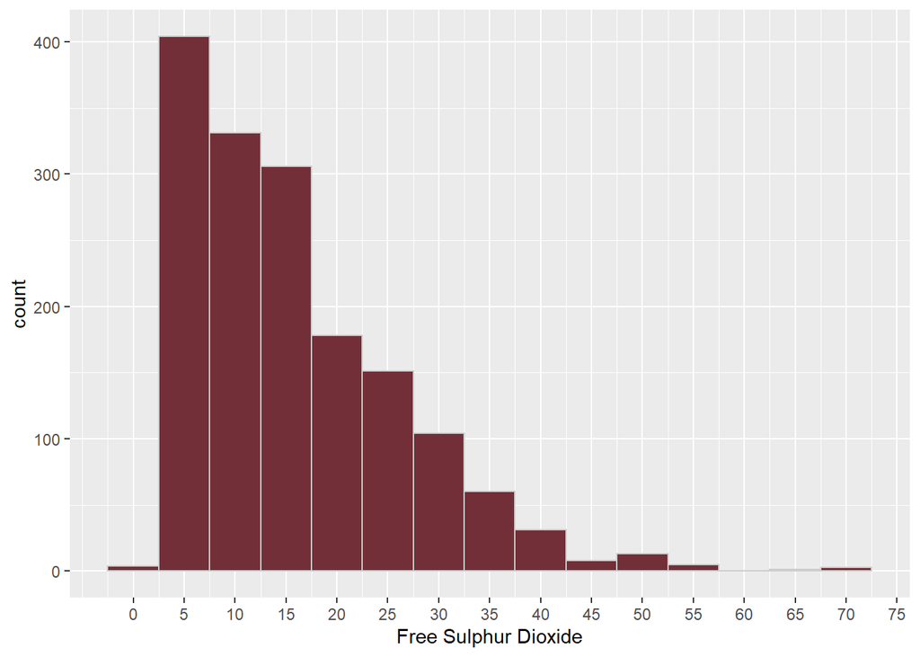

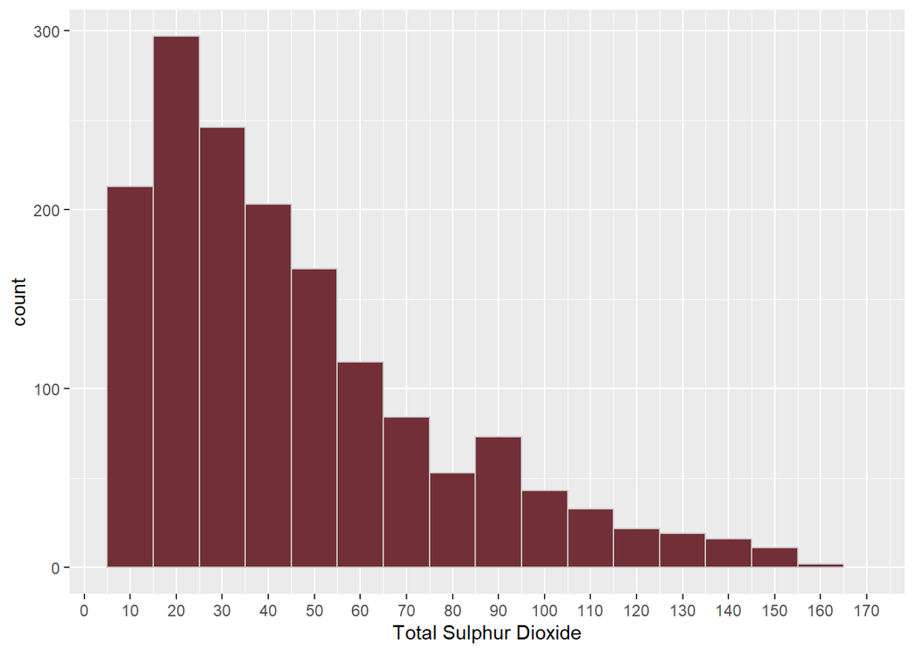

### I hope less preservatives is better. We’ll see.

### Chlorides. Ok now we have salt, acid, and sugar. Now I understand cheese

### being frequently paired with wine since fat is a nice way to round out salt,

### sugar, and acid

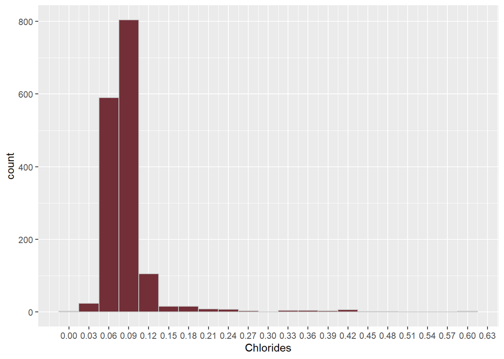

### this histogram has some wild outliers so I’m cutting off the tail

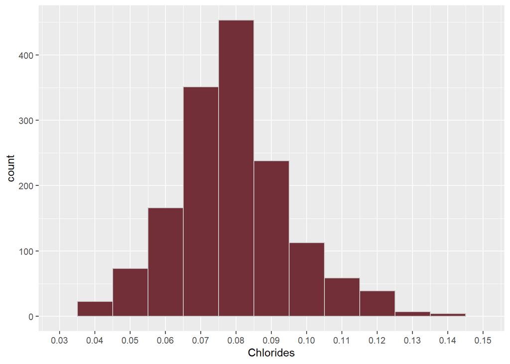

### That looks like something easier to get some meaning from.

### I’ve heard about pH being a thing with wine but I don’t know what’s supposed

### to be good. I’m guessing it’s supposed to be acidic like other fruit based

### drinks. I do know that 7 is neutral and lower than that for more acidic.

### Rough scale to see what’s there:

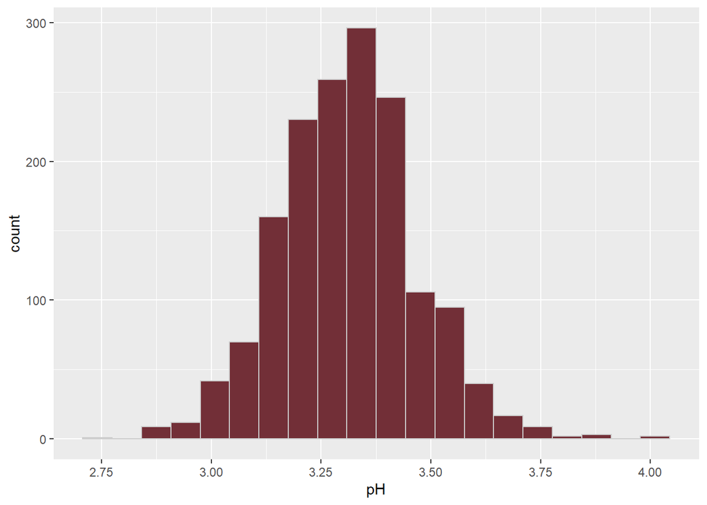

### Looks ok without tails chopped off. This stuff is way more acidic than

### coffee so I don’t want to ever hear from wine drinking dentists ever again.

### On to the sulphates. I don’t even like sulphates in my shampoo. In all

### fairness, I’ve never seen even the wildest lifehack videos on youtube

### recommending washing your hair with wine. Is this TMI yet? Will the team

### at Udacity start calling not-it when I turn things in? The rubric asks for

### a stream of consciousness though so here we are.

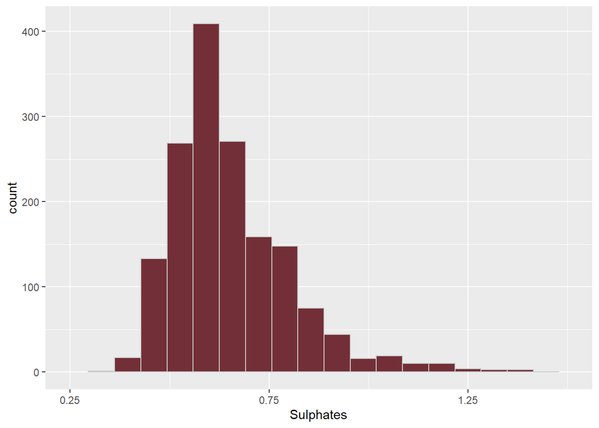

### Google says the sulphates are from pesticides. Yuck.

### On to the thing wine drinkers drink wine for, alcohol. I’m guessing it’s not

### vodka levels but let’s see what it looks like with no limits

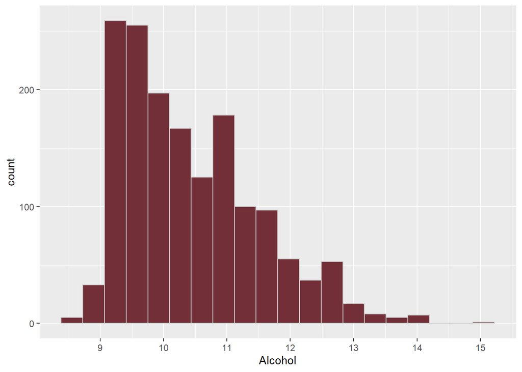

### I don’t know if that is a measure of proof, percent, or volume. Not that I

# Univariate Analysis

### What is the structure of your dataset?

- There are 1599 wines in the dataset and 12 variables of them are measured

### What is/are the main feature(s) of interest in your dataset?

- My main goal is to see which what combination of salt, acid, and sugar make a wine good

### What other features in the dataset do you think will help support your

### investigation into your feature(s) of interest?

- I’m pretty sure sulphates are going to have a negative effect.

### Did you create any new variables from existing variables in the dataset?

- I didn’t make up any variables.

### Of the features you investigated, were there any unusual distributions?

Did you perform any operations on the data to tidy, adjust, or change the form  
of the data? If so, why did you do this?

- I chose a tidy data set because I’m out of time for the semester and already did the data cleaning project. I did chop the tails off some skewed data to get a better look at some of the variables.

# Bivariate Plots Section

## Bivariate Analysis

### Here I’m going to look for some correlations between quality and things I’m

### guessing make it taste better because they’re usually what makes anything

### taste good. So we’re looking at salt, sugar, and acid with the possibility

### of sulphates messing up a good wine.

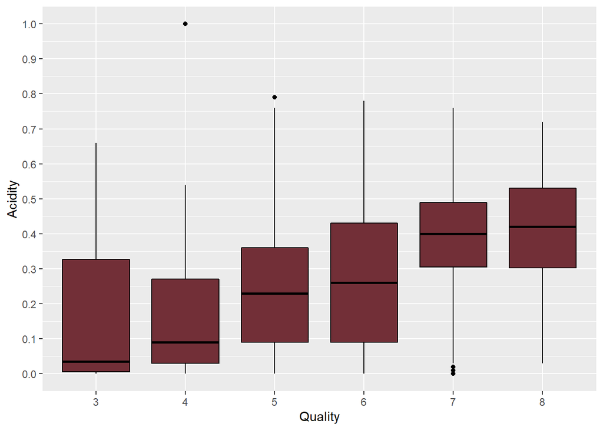

### Acid looks like a winner.

### Let’s look at sugar.

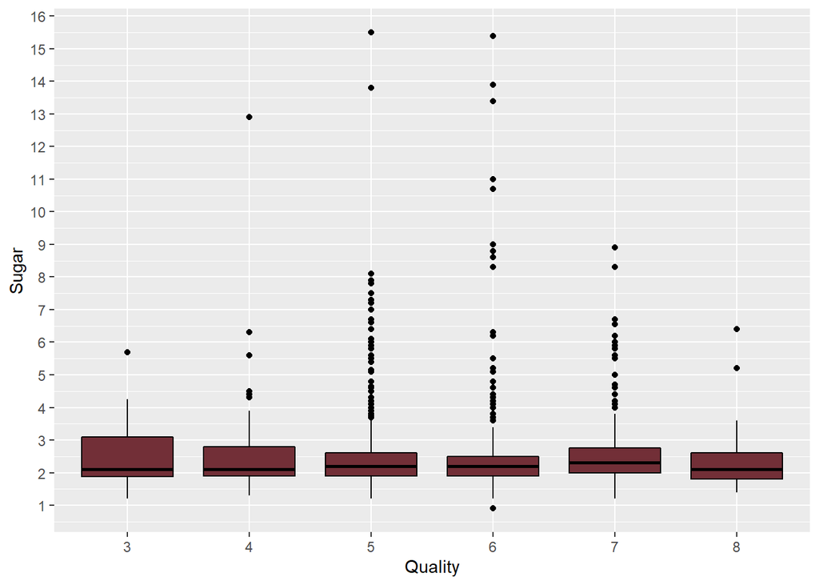

### That’s not what I expected. Pretty flat across the board here. Maybe there’s

### only so much sugar grapes can have and that’s that? Now I’m curious if

### anyone has made wine from moon drop grapes.

### Ok how about salt?

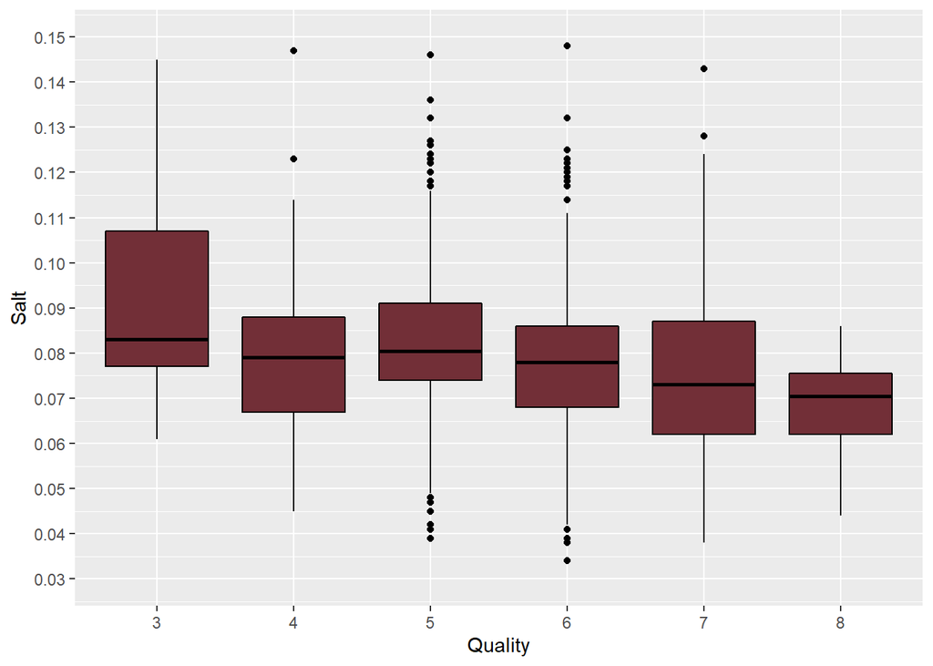

### Less salt looks better. That’s the opposite of what I expected. At least

### there’s a pattern though.

### Finally here’s sulphates. I want to see how pesticides affect quality.

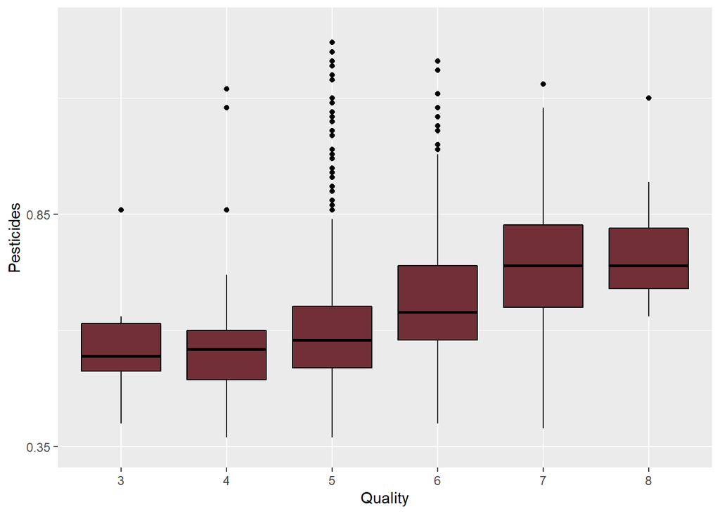

### More pesticides is good? Oh well. Melted styrofoam tastes good too as

### evidenced by dunkin donuts coffee.

### Is more alcohol good or bad? I don’t know but I’m curious.

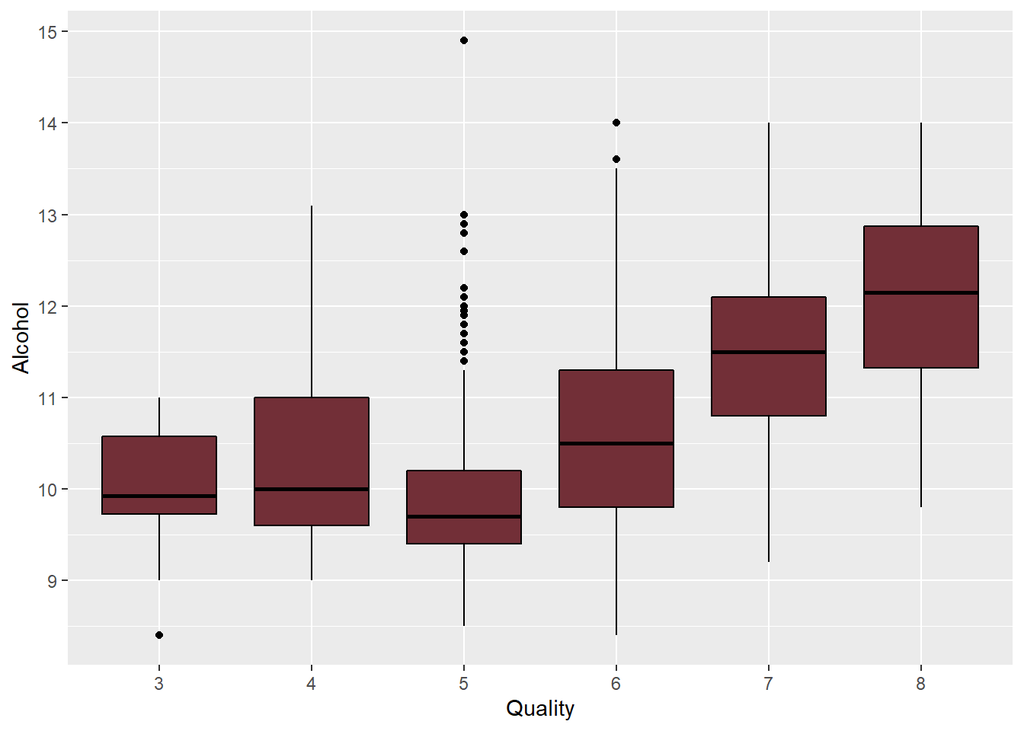

### This one looks like a pretty clear correlation.

### How did the feature(s) of interest vary with other features in the dataset?

- It appears less salt, more acid, and more alcohol all correlate to quality.

### Did you observe any interesting relationships between the other features

(not the main feature(s) of interest)?

- I really expected pesticides to have a negative effect but they didn’t.

### What was the strongest relationship you found?

- Alcohol content is the strongest relationship by far.

# Multivariate Plots Section

> **Tip**: Now it’s time to put everything together. Based on what you found in the bivariate plots section, create a few multivariate plots to investigate more complex interactions between variables. Make sure that the plots that you create here are justified by the plots you explored in the previous section. If you plan on creating any mathematical models, this is the section where you will do that.

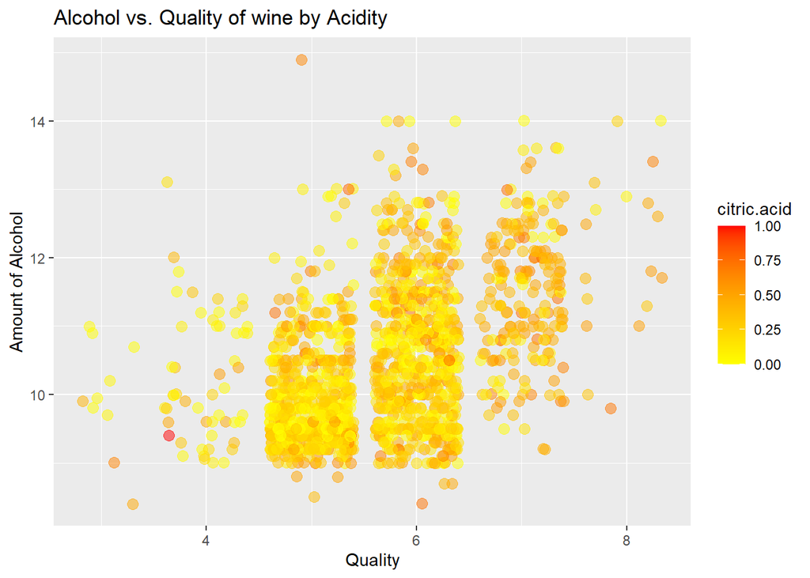

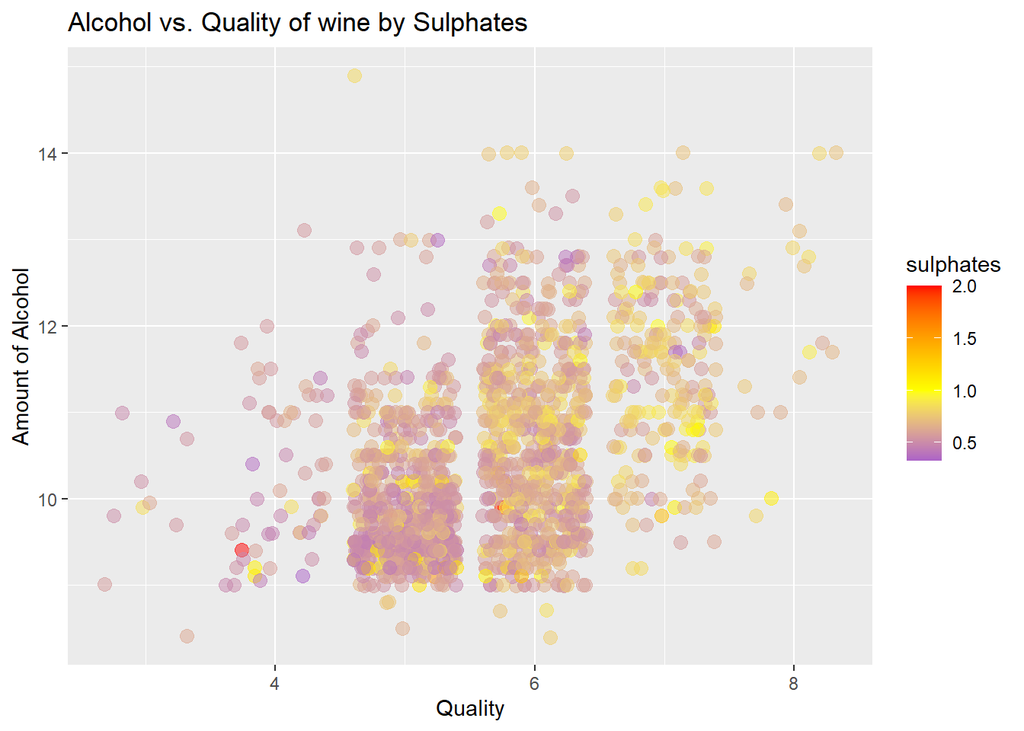

# Multivariate Analysis

### Talk about some of the relationships you observed in this part of the

investigation. Were there features that strengthened each other in terms of  
looking at your feature(s) of interest?

- Pesticides and citric acid appear to be helpers to the amount of alcohol that makes up a quality wine.

### Were there any interesting or surprising interactions between features?

- I really thought sulphates from pesticides would have the opposite effect.

# Final Plots and Summary

### Plot One

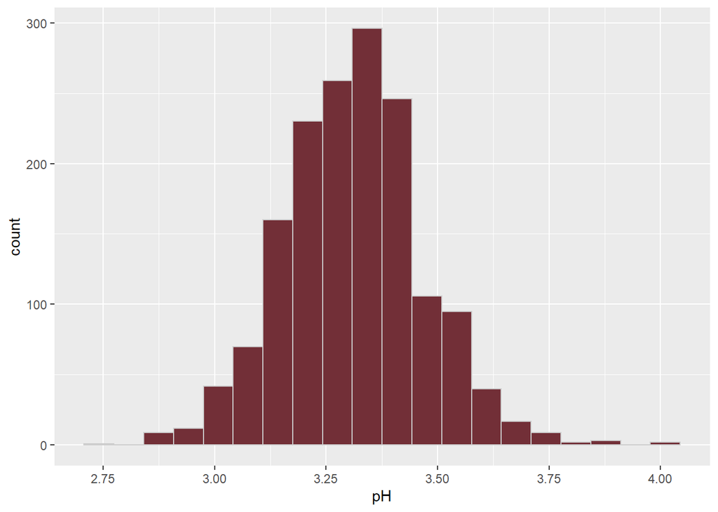

### I chose the pH histogram because I was really surprised to find that most

### wine is between 3.2 and 3.5 pH. Compared to coffee’s average of around 5,

### that’s very acidic. The popularity of alkaline water and wine right now

### among hipsters is a strange contrast.

### Plot Two

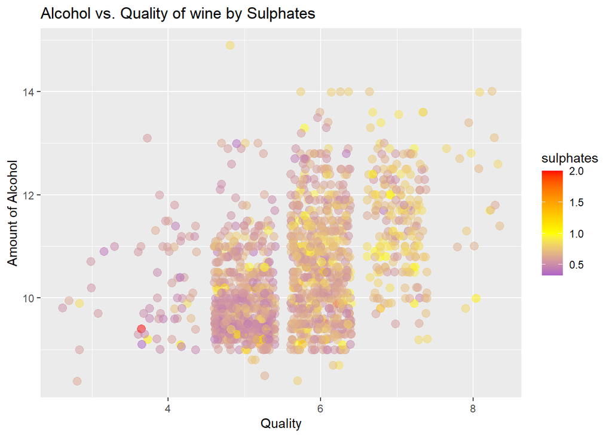

### Plot 2 is another one that surprised me. Sulphates in wine are a result of

### pesticides being sprayed on grapes. I get that grapes are a fragile fruit

### and pesticides keep whole crops from being destroyed, but I really didn’t

### expect their presence to enhance quality.

### Plot Three

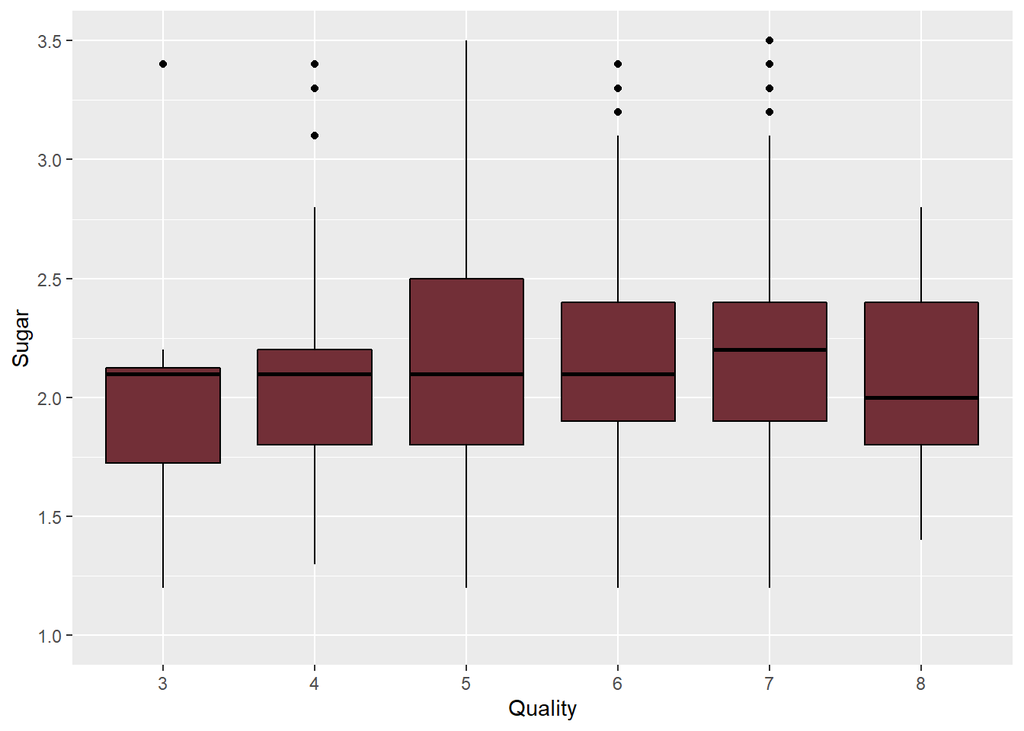

### Plot 3 was chosen because I really expected more sugar to correlate to a

### wine being higher quality since what makes grapes tasty is thier sweetness.

### I was surprised to see a basically flat line when compared to quality. Even

### after zooming in on the box plots by cutting off some outliers, the drop off

### in sugar for the highest quality wines ruins the positive correlation.

# Reflection

Wine has been credited for various healthy properties like being high in resveratrol and other antioxidants. Considering the acidity though, it’ll likely wreck your teeth. My cooking experience had me expecting salt, sweet, and acid to be what makes it taste good. I’m not convinced by these results that Quality is related it tasting good since higher sulphates correlated with quality. Also, salt usually makes things taste better even when their supposed to be sweet, but here we find that salt had a negative correlation with quality.